# Projekt 2, faza 2

Ewelina Karbowiak, Adrianna Wlazło

16 stycznia 2017

**Temat** Celem projektu jest zbadanie, jaki wpływ na końcowe wyniku testu ma przyjęta strategia rozwiązywania zadań przez uczniów.

# Dane

Dane pochodzą z projektu PISA 2015. Zawierały 8 557 694 wierszy opisujacych czas rozwiązywania danego zadania przez danego ucznia. Dane zawierają informacje o kraju i szkole, z której pochodził uczeń, numer rozwiązywanego zestawu, typ zadania (czytanie, matematyka) oraz numer części testu, w kt órej to zadanie się znajdowało. Aby ułatwic prace nad danymi zamieniłyśmy czas podany w tysięcznych sekundy na minuty.

**Faza 2** W raporcie posłużymy się danymi oczyszczonymi w fazie 1. Spróbujemy zróżnicować zachowania studentów różnych szkół w zależnosci od czasu rozwiązywania zadań w różnych pozycjach testu oraz zależnie od obszaru.

## Szkoły-zadania

Wstepnie przeprowadzimy analizę hierarchicznę na średnich czasach rozwiązywania każdego z zadań dla szkół. W danych nie było ucznia, który rozwiązał wszystkie zadania dostępne w bazie. Jednak gdy rozważamy całą szkołę okazało się, że jest bardzo niewiele przypadków, że konkretne zadanie nie zostało rozwiązane przez żadnego ucznia z danej szkoły. W tych nielicznych przepadkach za średni czas przyjmowałyśmy 0.

| Szkola | M00GQ01 | M00KQ02 | M033Q01 | M034Q01 | M155Q01 | M155Q02 | M155Q03 | M155Q04 | M192Q01 | M273Q01 | M305Q01 | M406Q01 | M406Q02 | M408Q01 | M411Q01 | M411Q02 | M420Q01 | M423Q01 | M442Q02 | M446Q01 | M446Q02 | M447Q01 | M462Q01 | M464Q01 | M474Q01 | M496Q01 | M496Q02 | M559Q01 | M564Q01 | … |
| --- | --- | --- | --- | --- | --- | --- | --- | --- | --- | --- | --- | --- | --- | --- | --- | --- | --- | --- | --- | --- | --- | --- | --- | --- | --- | --- | --- | --- | --- | --- |
| 3600001 | 2.3100917 | 0.9637667 | 0.9872667 | 1.774696 | 1.0034333 | 2.830429 | 3.053929 | 1.017283 | 0.961000 | 1.328733 | 0.9631167 | 0.740100 | 0.1719833 | 1.299139 | 2.484113 | 0.8236042 | 1.381067 | 0.4480500 | 2.452650 | 1.496933 | 3.290017 | 0.8717500 | 2.370292 | 1.1586000 | 0.7907042 | 0.6783833 | 2.8653000 | 1.624028 | 3.3826167 | … |
| 3600002 | 0.9751167 | 1.4941250 | 0.7733250 | 1.184650 | 1.4350750 | 2.226075 | 3.928150 | 1.129192 | 1.360250 | 1.290625 | 1.1469333 | 1.596167 | 1.2301333 | 1.195146 | 2.745333 | 1.0200083 | 1.024054 | 0.4832667 | 2.622483 | 1.317354 | 1.461746 | 1.0966292 | 2.758883 | 1.1949750 | 0.5383000 | 1.1676333 | 1.3622833 | 1.596392 | 0.7885833 | … |
| 3600003 | 2.6070611 | 1.8883800 | 0.6273722 | 1.146072 | 1.4735778 | 4.049506 | 1.557067 | 2.528083 | 1.486336 | 1.708531 | 1.6953619 | 1.811000 | 1.6140194 | 1.671625 | 3.694911 | 1.1015167 | 1.358000 | 0.6411556 | 3.452967 | 1.210803 | 2.506330 | 1.5696028 | 2.242856 | 1.5619222 | 1.0652889 | 2.1170083 | 1.1548139 | 1.605533 | 1.0887056 | … |
| 3600004 | 1.3313500 | 1.4075750 | 0.8934889 | 1.950517 | 0.9989833 | 1.699156 | 2.384389 | 1.706250 | 1.313262 | 2.885475 | 0.9723875 | 3.747012 | 3.0603208 | 1.229850 | 1.957594 | 1.7385167 | 1.250317 | 0.5420542 | 2.617456 | 1.068358 | 2.528358 | 0.9993333 | 2.103906 | 1.1875667 | 0.7246111 | 1.1871125 | 0.7506042 | 1.769850 | 0.8546958 | … |
| 3600005 | 1.8396583 | 2.5239250 | 0.6859133 | 1.625180 | 1.0509933 | 1.927340 | 2.760653 | 1.052160 | 1.286033 | 2.467467 | 0.9950083 | 3.208442 | 3.3636250 | 1.667283 | 2.390790 | 1.2947400 | 1.589300 | 0.3049417 | 2.868723 | 1.432175 | 2.934450 | 1.2111583 | 1.451820 | 0.9809667 | 0.6165000 | 2.3577833 | 0.6743583 | 1.913058 | 0.8944917 | … |
| 3600006 | 2.4676667 | 1.5530333 | 0.8542167 | 1.532758 | 1.2970833 | 1.810542 | 3.492808 | 0.975925 | 1.264408 | 1.879183 | 1.0792917 | 1.664417 | 2.2577250 | 1.414325 | 1.735350 | 0.6448667 | 1.396383 | 0.4212333 | 2.125658 | 1.249725 | 2.840000 | 3.0499750 | 3.798442 | 1.1265917 | 0.4457250 | 1.2184000 | 1.0430708 | 1.489058 | 0.9419833 | … |

Dendogramy wykonywałyśmy metodą **ward.D2** za pomocą funkcji **hclust**. Analiza dendogramu skłoniła nas do wybrania 4 grup.

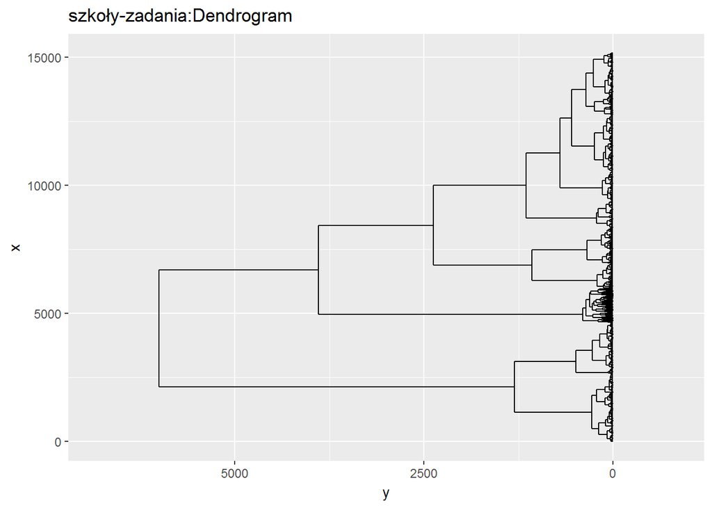

### Różna liczba grup

Przedstawiamy zmapowane podziały dla k od 2 do 9. Rozkład punktów różni się między wykresamu, ze względów obliczeniowych- są to reprezentacje najbardziej uwydatniające dany podział. Dla każdego podziału za pomocą createFolds została wylosowana reprezentatywna próbka z danych względem wyróżnionych grup, a w kolejnym kroku przeprowadzone zostało mapowanie.Analiza poniższych wykrsów róWnież wskazuje na wybór 4 grup.

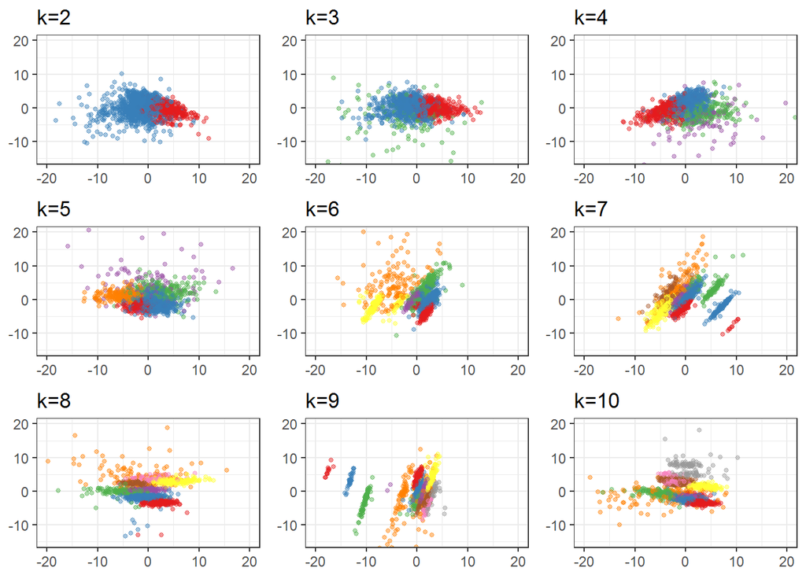

```
## Liczności grup
```

```
##
##    1    2    3    4
## 4659 6818 2371 1318
```

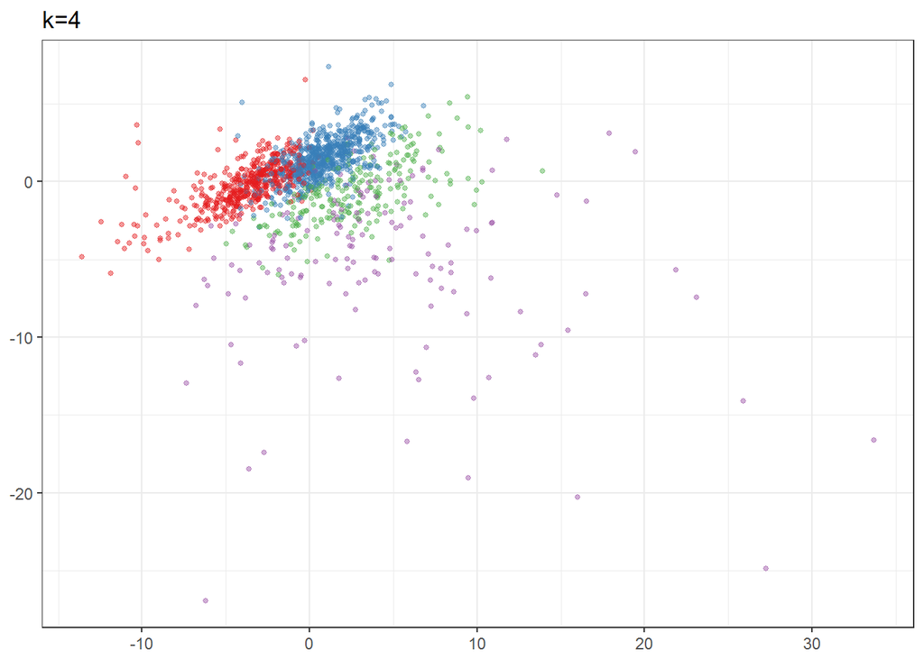

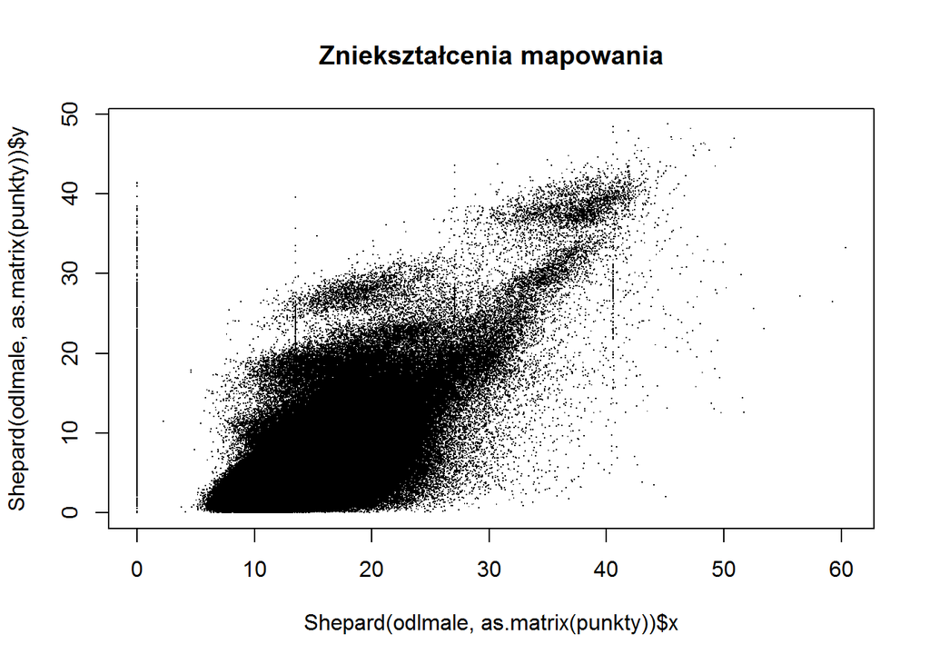

Poniżej przedstawiamy boxploty przedstawiajace rozkład czasu rozwiazania przykładowego zadania w zależności od tego, do której grupy zostały przydzielone.

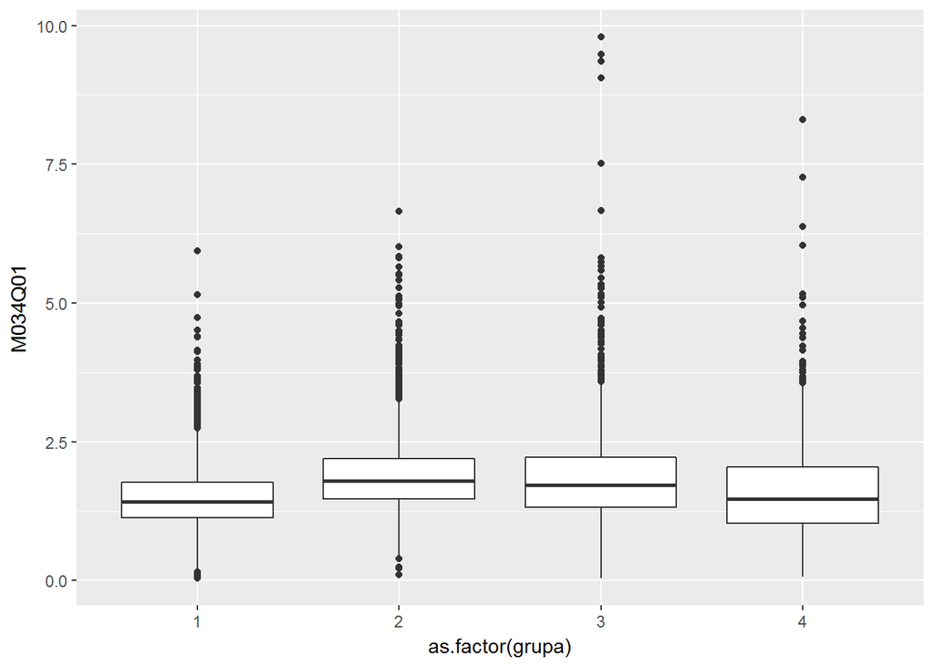

Ze względu na liczebność zadań trudno jest nazwać wszystkie wzorce zachowań tak, aby każde niosło ze sobą jasną informację. Aby poprawinie wyodrębnić 4 grupy stworzyłyśmy ranking, który porównuje w ilu zadaniach dana grupa była szybsza od pozostałych.

```
##
##     miejsce 1 miejsce 2 miejsce 3 miejsce 4
##   1       170         1         0        11
##   2        11        62         1       108
##   3         1        84        36        61
##   4         0        35       145         2
```

I tak:

| nr_grupy | nazwa |
| --- | --- |
| 1 | naszybsi |
| 2 | najwolniejsi z szybszymi momentami |
| 3 | nierówni i nieszybcy |
| 4 | wolni |

## Szkoła-pozycje

Analizując strategie uczniów, warto zbadać średni czas wykonywania zadań w każdej z pozycji zależnie od szkoły. Szybkośc rozwiązywania poszczególnych pozycji może być istotnym elementem strategii.

| Szkola | 1 | 2 | 3 | 4 |
| --- | --- | --- | --- | --- |
| 3600001 | 1.714738 | 1.476135 | 1.287331 | 1.073811 |
| 3600002 | 1.383775 | 1.348908 | 1.364129 | 1.297679 |
| 3600003 | 2.054243 | 1.480850 | 1.416849 | 1.435354 |
| 3600004 | 1.330350 | 1.298852 | 1.271818 | 1.368307 |
| 3600005 | 1.888812 | 1.504586 | 1.699385 | 1.903631 |
| 3600006 | 1.574090 | 1.206749 | 1.558074 | 1.370092 |

Na tak przygotowanych danych przeprowadzamy analizę hierarchiczną metodą **Warda**. Poniżej przedstawiamy dendrogram.

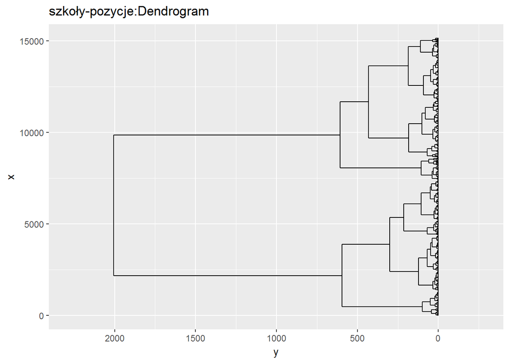

Nie jest jasne, ile grup nalezy wyróżnić. Poniżej wykresy dla podziałów na 2-9 grup zmapowanych na płaszczyznę. Rozkład punktów różni się między wykresamu, ze względów obliczeniowych- są to reprezentacje najbardziej uwydatniające dany podział. Dla każdego wylosowana została reprezentatywna względem wyróżnionych grup próbka z danych, a w kolejnym kroku przeprowadzone zostało mapowanie.

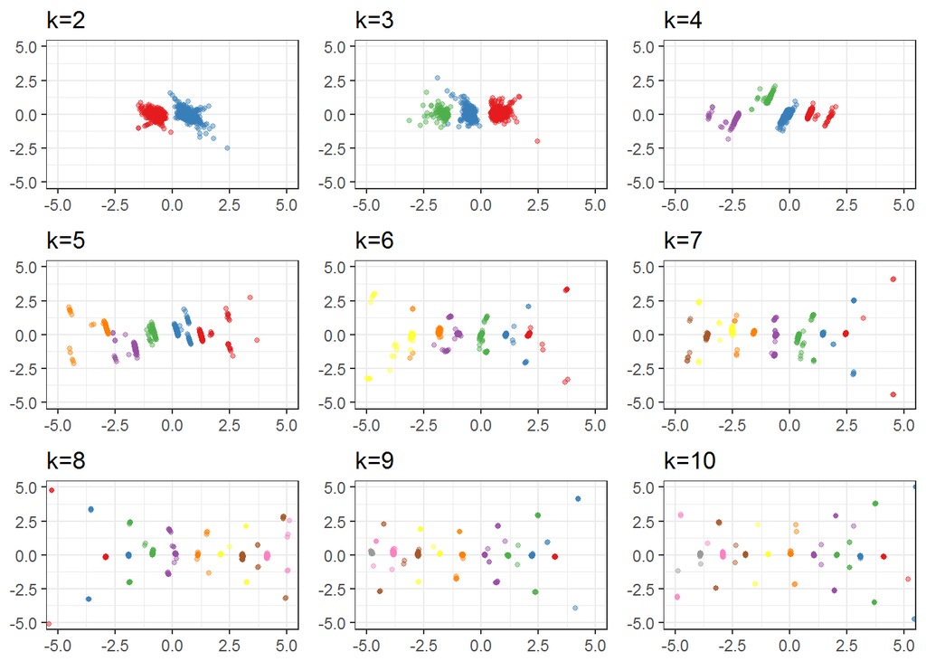

Dla podziałów większych niż k=5 widać duże rozbieżności wewnątrz grup, co sugeruje, że nie są to optymalne podziały.

```
## Liczność poszczególnych grup
```

```
##    1    2    3    4    5
## 6124 3107 3406 1318 1211
```

Spróbujmy rozróżnić zachowania szkół wśród wyróżnionych grup względem średniego czasu spędzanego nad zadaniem z każdej pozycji.

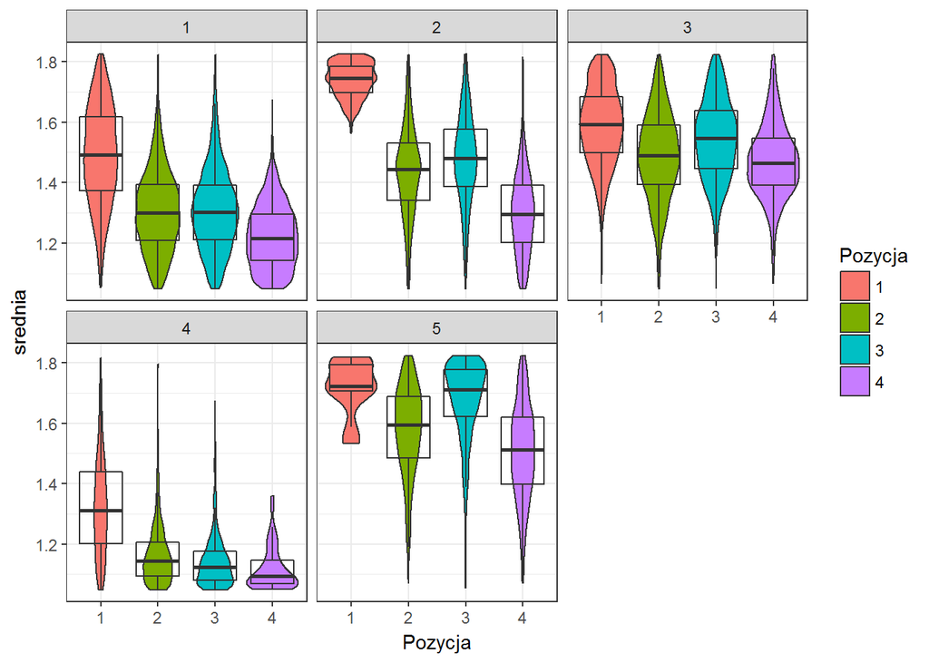

Na powyższych wykresach bardzo wyraźnie widać różnice między grupami. Na ich podstawie możemy nazwać zachowania poszczególnych grup szkół:

| Grupa | Czasy |
| --- | --- |
| 1 | coraz szybciej- wersja wolniejsza |
| 2 | długie zastanawianie się w 1 |
| 3 | dość równe |
| 4 | coraz szybciej- wersja szybsza |
| 5 | długo w 1, poza tym dość równo |

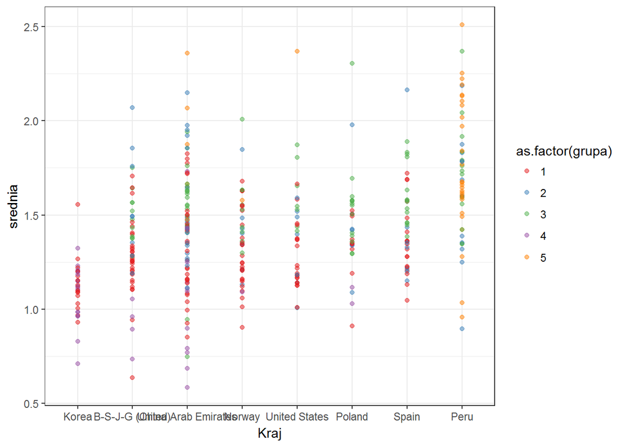

## Szkoły- pozycje po uczniach

Spróbujemy zbadac zachowania uczniów alternatywnie: obliczymy średni czas rozwiązywania zadań wg pozycji i ucznia, a następnie wyznaczymy średnią i odchylenie standardowe wśród szkół- będzie to pewna miara rozróżnialności studentów w obrębie danej szkoły.

| Szkola | srednia1 | srednia2 | srednia3 | srednia4 | odch1 | odch2 | odch3 | odch4 |
| --- | --- | --- | --- | --- | --- | --- | --- | --- |
| 3600001 | 1.725328 | 1.505690 | 1.301199 | 1.090902 | 0.5167502 | 0.6133427 | 0.2978398 | 0.3378186 |
| 3600002 | 1.391060 | 1.367396 | 1.393852 | 1.405328 | 0.4473599 | 0.4402754 | 0.5464323 | 0.8220879 |
| 3600003 | 2.062557 | 1.644166 | 1.450129 | 1.466194 | 0.4922954 | 0.5888146 | 0.6765719 | 0.5014284 |
| 3600004 | 1.339047 | 1.316822 | 1.297330 | 1.400551 | 0.3493926 | 0.4077437 | 0.4179328 | 0.4258451 |
| 3600005 | 1.921010 | 1.509501 | 1.687958 | 1.888307 | 0.5608873 | 0.3947939 | 0.5931460 | 0.5184271 |
| 3600006 | 1.594515 | 1.227534 | 1.561215 | 1.377268 | 0.2347127 | 0.4316852 | 0.1110439 | 0.1217776 |

Dla tak przygotowanych danych rodzielamy dane na grupy używając algorytmu k-medoidów.

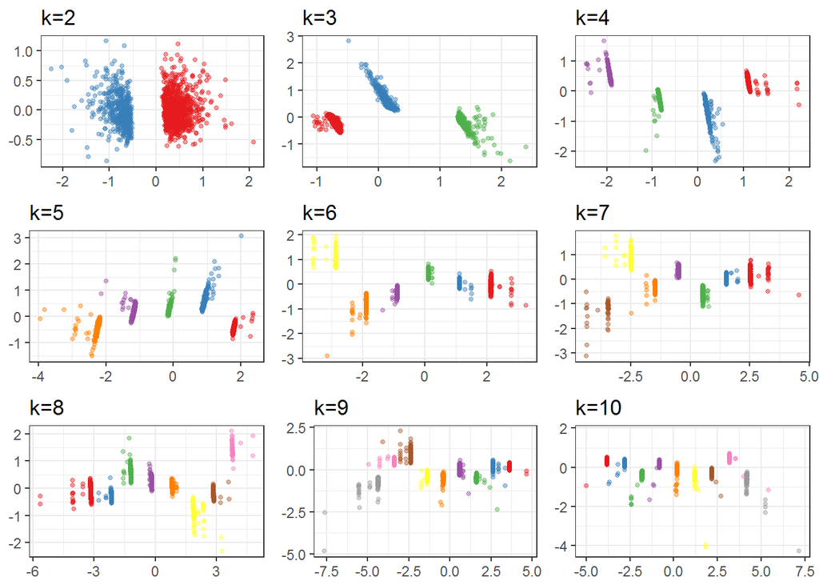

Wybieramy podział 4-medoidów.

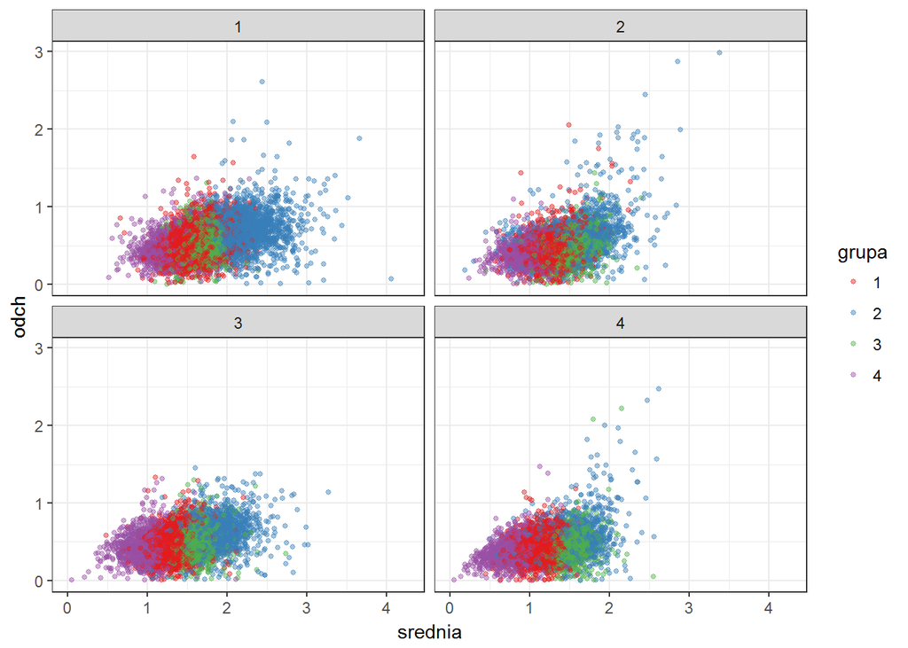

Powyżej mamy statystyki dla poszczególnych grup w zalezności od pozycji (panel~pozycja).

## szkoły-obszary

Kolejnym interesującym nas zagadnieniem była zalezność czasu rozwiązywania zadań od obszarów. Szybkość rozwiazywania zadań z danego obszaru może być spowodowany systemem edukacji, jaki panuje w danym kraju i podejściem do danego obszaru w tym kraju.

Analiza dendrogramu i wykresów dla podziałów na 2-9 grup zmapowanych na płaszczyznę skłoniła nas do wybrania 6 grup.

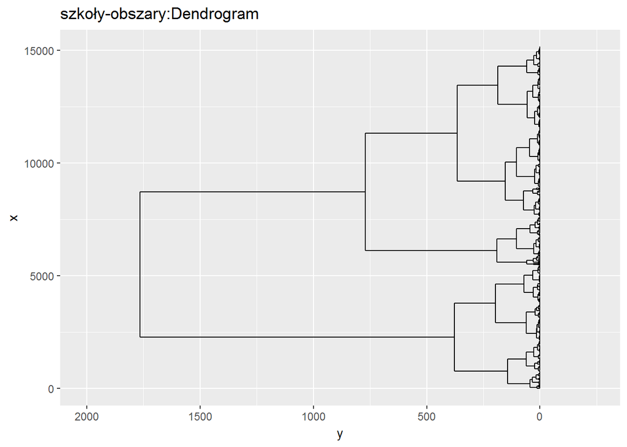

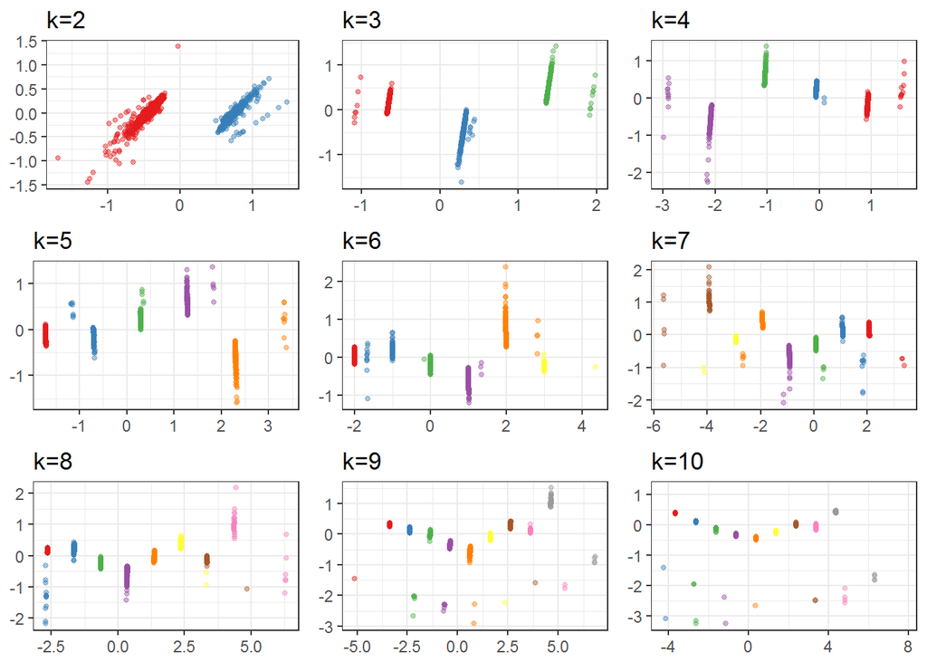

```
## Liczności grup
```

```
##    1    2    3    4    5    6
## 3627 3904 1692 2136 2167 1640
```

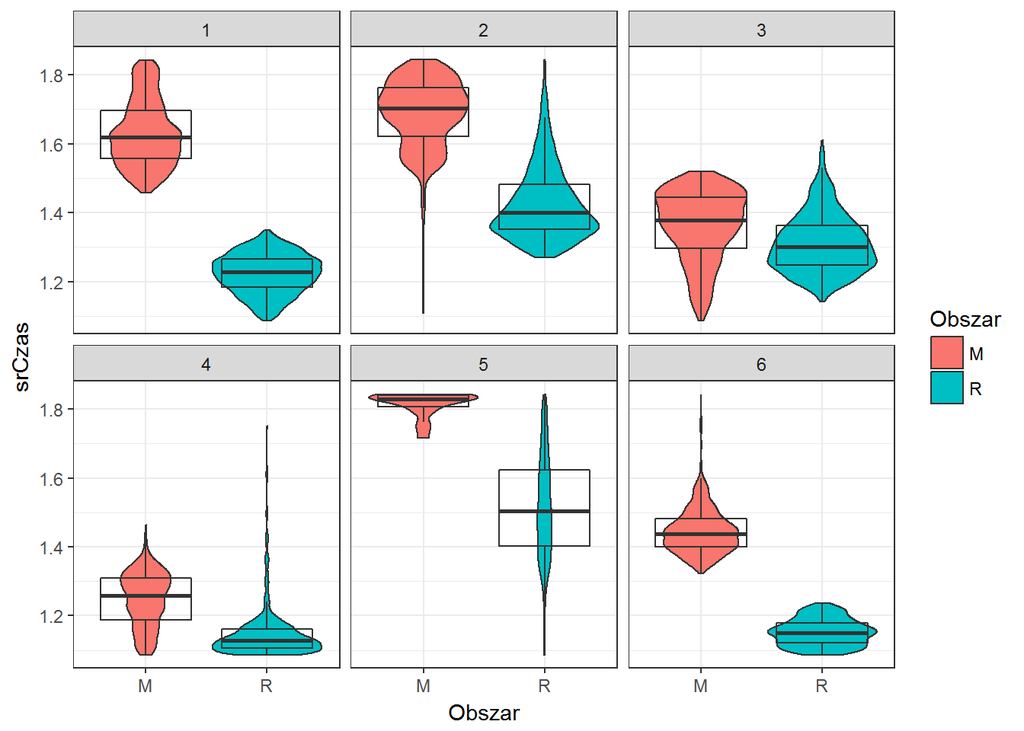

Powyższe wykresy skrzypcowe potwierdzają zróżnicowanie wybranych grup pod względem średniego czasu rozwiązwywania zadań dla obszaru matematycznego i czytania. Na podstawie tych wykresów możemy nazwać zachowania poszczególnych grup szkół:

[output not shown]

Po raz kolejny warto spojrzeć jak poszczególne grupy mają się do poszczególnych krajóW.

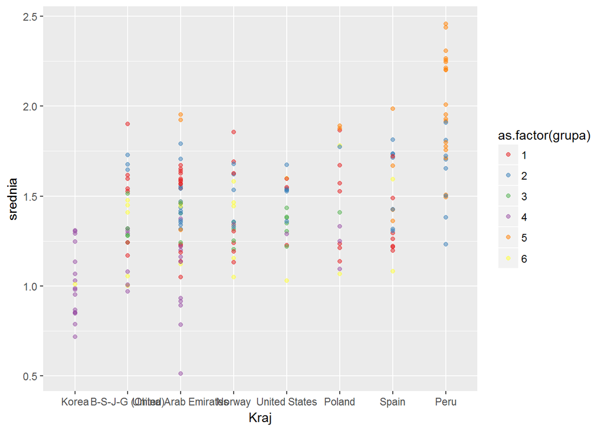